# Effects of the Rides Characteristics on The duration

## Investigation Overview

In this investigation, I wanted to look at the characteristics of the trip ride that could be of Influence to determine the duration. The main focus is on: Age, hour, day, user type and gender.

## Dataset Overview

The data consisted of 174952 samples and 19 features of users. The features included the Age, hour, day, user_type as well as other attributes such as start_station id, end station_id, gender, bike share, etc. This is a cleaned dataset, some wrangling were done in this dataset from the previous section, in which missing data where dropped and some changes were performed on some datatypes for effective analysis.

## Distribution of Duration(sec)

The distribution has a long tail when plotted on a standard scale, In other to have a clearer view of the distribution, we transformed the plot the duration_sec using a log-scale. The distribution is a unimodal, with more number of trips covered below 2000sec and having it's peak around 600sec then starts to fall around 800sec to 20000sec

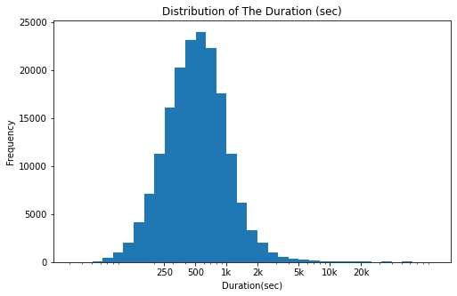

### Distribution of Age(years)

This distribution tells us the range in ages of users in the dataset and what age group or range of age participated more. Plotting the distribution on a log scale showed that more young people participated between the age of 20 and 40.

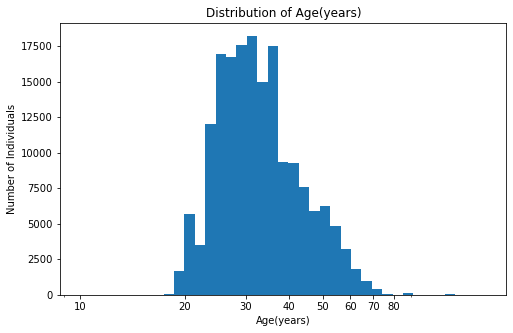

### Percentage of the User Types

Viewing the percentage of User types in the datasets in a pie chart, shows that there is higher percentage of subscribers of about to 90.5% in comparison with 9.5% of customers users.

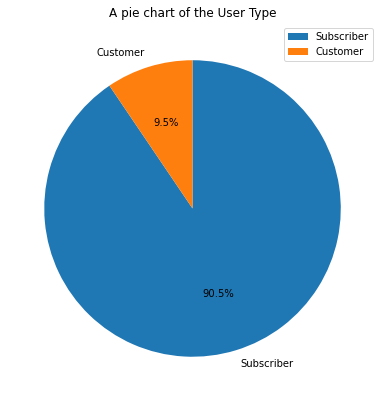

## Duration and Age

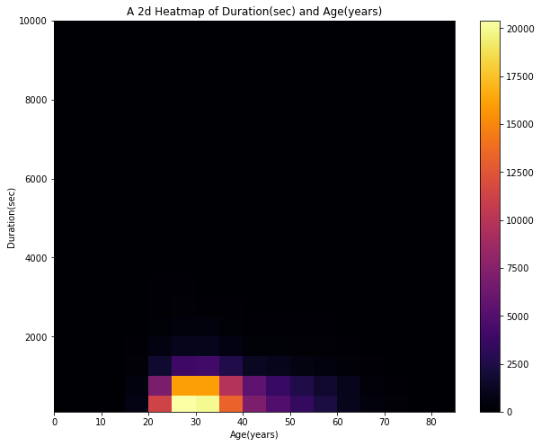

## Duration vs Gender and Duration vs User Type

We see that despite the percentage of male being the most users in the distribution of the member_gender, when compare with the duration we have more percentage of female and other genger riding longer than the male. Likewise in user_type we observed that higher percentage of customers make longer trip in comparison with the subscribers.

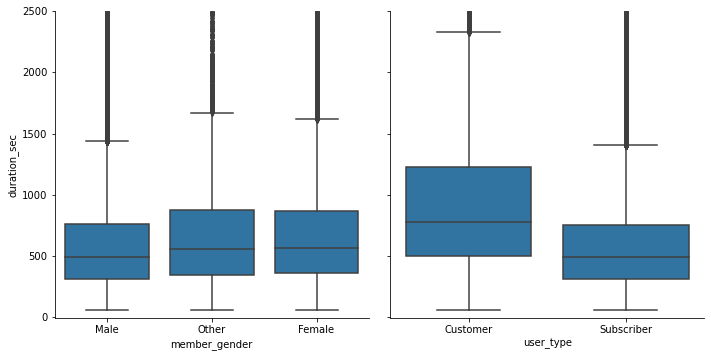

### Rides Duration, Day and User Type

Customers have tend to spend more trip time with most duration occuring during weekends and subscribers having being consistent in their rides duration with little increase on weekends.

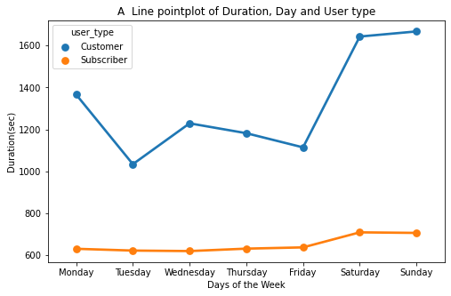

### Rides Duration, Gender and User Type

We have it that more percentage of other gender spend more duration on trips for both customers and subscribers than any other gender, with the females being the second more and males being the least.

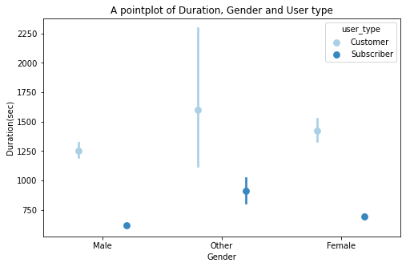